# Pump_it_Up

##### POPULATION

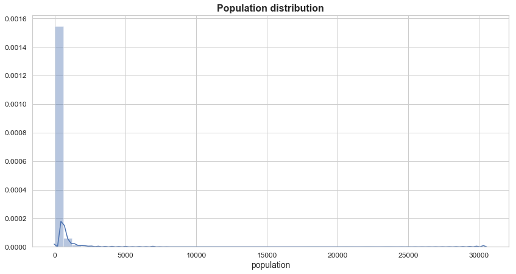

```python
plt.figure(figsize=(14, 7))
sns.distplot(train['population']);
plt.title("Population distribution", fontsize=16, fontweight='bold')
```

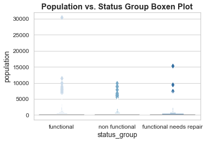

```python
sns.boxenplot(x=train['status_group'], y=train['population'],data=train, palette="Blues");
plt.title("Population vs. Status Group Boxen Plot", fontsize=16, fontweight='bold')
```

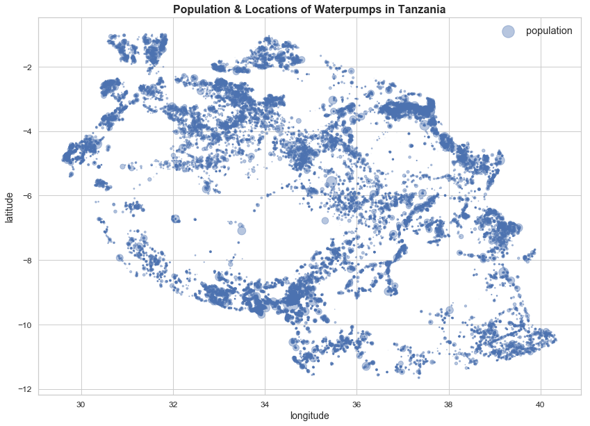

```python
train[train['longitude']>0] [train['latitude']<0].plot\
(kind='scatter', x="longitude", y="latitude", alpha=0.4,
s=train["population"]/50, label="population", figsize=(14,10));
plt.title("Population & Locations of Waterpumps in Tanzania",
         fontsize =16, fontweight='bold')
plt.legend;
```

### Correlations Heatmap

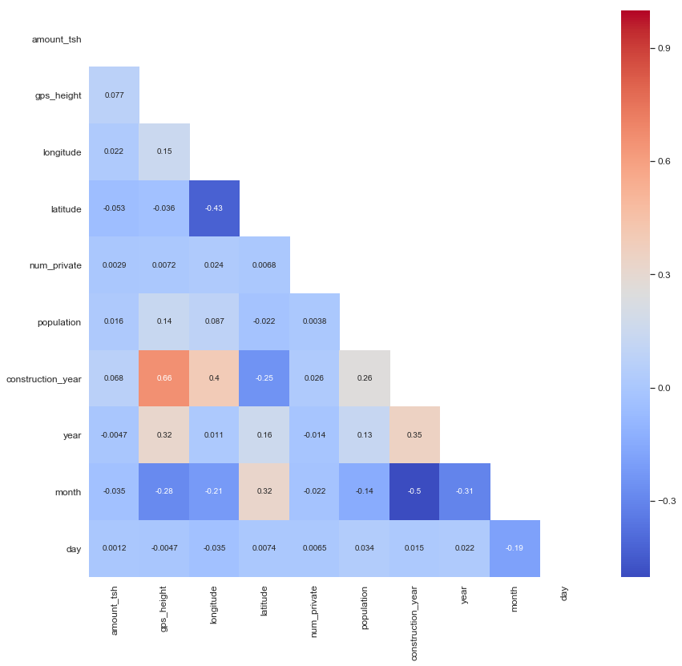

```python
corr_table = train.corr()
plt.figure(figsize=(14,13))
mask = np.zeros_like(train.corr(), dtype=np.bool)
mask[np.triu_indices_from(mask)] = True
sns.heatmap(train.corr(),cmap='coolwarm',mask=mask, annot=True);
#sns.heatmap(corr_table, square=True, annot=True, cbar=False, cmap="coolwarm");
```

## Data cleaning and features creation

### Latitude, Longitude, Gps_height, Distance

#### Feature Creation attempt: distance

We tried to create a distance feature with two different approaches, as you can see in the cell below as comments. However, it actually worsened our score, hence it is commented out in this section.

```python
# mean_lat_train = train['latitude'].mean()
# mean_long_train = train['longitude'].mean()
# mean_lat_test = test['latitude'].mean()
# mean_long_test = test['longitude'].mean()

# train['distance'] = np.sqrt((train['longitude'] - mean_long_train)**2 + (train_x['latitude'] - mean_lat_train)**2)
# test['distance'] = np.sqrt((test['longitude'] - mean_long_test)**2 + (test_x['latitude'] - mean_lat_test)**2)

# train['distance3d'] = np.sqrt((train['gps_height']**2 + train['longitude'] - mean_long_train)**2 + (train_x['latitude'] - mean_lat_train)**2)
# test['distance3d'] = np.sqrt((test['gps_height']**2 + test['longitude'] - mean_long_test)**2 + (test['latitude'] - mean_lat_test)**2)
```

#### Imputation of missing coordinates and their corresponding elevation in Train and Test dataset with the help of CARTO and Googlemaps Api

1. Join train and test datasets from website in Dataiku
2. Upload joined dataset to Carto
3. Remove outliers with longitude 0 (points in the Atlantic Ocean) from the dataset

> **Sidenote:** only values from the Lake Victoria region and a few select from the Lake Tanganyika region had missing Coordinates
> 1. Color each pump based on the basin it gets its water from. In total all pumps have 9 sources of water.
1. Use “Create Centroids of Geometries” analysis feature and categorize by basin.  
   This will give you the center longitude and latitudes for each of the 9 basins **(see picture below)**

```python
from IPython.display import Image
from IPython.core.display import HTML
Image(url= "https://github.com/Fe1ix789/Pump_it_Up-Machine-Learning-Project/blob/master/Screenshot1.png?raw=true")
```

[figure not shown]

1. Export this layer with these 9 coordinates

| Longitude | Latitude | Basin |
| --- | --- | --- |
| 34.247699 | -9.704374 | Lake Nyasa |
| 32.37766 | -8.27714 | Lake Rukwa |
| 38.316789 | -10.485215 | Ruvuma / Southern Coast |
| 34.94976 | -4.160205 | Internal |
| 32.76071 | -2.241567 | Lake Victoria |
| 35.843582 | -8.398101 | Rufiji |
| 37.621 | -3.925305 | Pangani |
| 31.210782 | -4.60315 | Lake Tanganyika |
| 37.892587 | -6.584803 | Wami / Ruvu |

1. As mentioned in **point 3**, only coordinates in the Lake Victoria region and Lake Tanganyika region had missing coordinates.  
   We replace these with the imputed coordinates in part 6 using Dataiku and a newly downloaded Train and Test dataset.
2. In addition, we noticed that all these missing coordinates we imputed also had missing GPS heights.  
   Therefore, we used the Googlemaps API to calculate the Elevation for Lake Victoria and Lake Tanganyika.

```python
!pip install -U googlemaps
```

```python
import googlemaps
from datetime import datetime
gmaps = googlemaps.Client(key='Your Googlemaps API key here')

# Get API key from https://developers.google.com/maps/documentation/javascript/get-api-key
```

1. Calculating the elevation of Lake Victoria using the GPS coordinates **from point 6**

```python
gmaps.elevation((32.76071,-2.241567))
```

1. Calculating the elevation of Lake Tanganyika using the GPS coordinates **from point 6**

```python
gmaps.elevation((31.210782,-4.60315))
```

#### Data Reload

After the imputation of the coordinates that we have obtained above through the use of external tools (namely CARTO and google maps) we now need to reload the dataset with the correct longitudes and latitudes in order to continue with the data cleaning.

```python
train = pd.read_csv("/Users/legiando/Desktop/MLII_Assignment_AnggieCleliaFelixLeon/Modelling_Data/trainingset_v.csv")
idtrain = train["id"]
train.drop(columns=["id"], inplace=True)
```

```python
train_y = pd.read_csv("/Users/legiando/Desktop/MLII_Assignment_AnggieCleliaFelixLeon/Modelling_Data/trainset_labels.csv",
               index_col = "id")
```

```python
test = pd.read_csv("/Users/legiando/Desktop/MLII_Assignment_AnggieCleliaFelixLeon/Modelling_Data/testset_v.csv")
idtest = test["id"]
test.drop(columns=["id"], inplace=True)
```

```python
total_data = pd.concat([train, test], sort = False)
total_data.head()
```

|  | amount_tsh | date_recorded | funder | gps_height | installer | longitude | latitude | wpt_name | num_private | basin | ... | payment_type | water_quality | quality_group | quantity | quantity_group | source | source_type | source_class | waterpoint_type | waterpoint_type_group |
| --- | --- | --- | --- | --- | --- | --- | --- | --- | --- | --- | --- | --- | --- | --- | --- | --- | --- | --- | --- | --- | --- |
| 0 | 6000.0 | 2011-03-14 | Roman | 1390 | Roman | 34.938093 | -9.856322 | none | 0 | Lake Nyasa | ... | annually | soft | good | enough | enough | spring | spring | groundwater | communal standpipe | communal standpipe |
| 1 | 0.0 | 2013-03-06 | Grumeti | 1399 | GRUMETI | 34.698766 | -2.147466 | Zahanati | 0 | Lake Victoria | ... | never pay | soft | good | insufficient | insufficient | rainwater harvesting | rainwater harvesting | surface | communal standpipe | communal standpipe |
| 2 | 25.0 | 2013-02-25 | Lottery Club | 686 | World vision | 37.460664 | -3.821329 | Kwa Mahundi | 0 | Pangani | ... | per bucket | soft | good | enough | enough | dam | dam | surface | communal standpipe multiple | communal standpipe |
| 3 | 0.0 | 2013-01-28 | Unicef | 263 | UNICEF | 38.486161 | -11.155298 | Zahanati Ya Nanyumbu | 0 | Ruvuma / Southern Coast | ... | never pay | soft | good | dry | dry | machine dbh | borehole | groundwater | communal standpipe multiple | communal standpipe |
| 4 | 0.0 | 2011-07-13 | Action In A | 0 | Artisan | 31.130847 | -1.825359 | Shuleni | 0 | Lake Victoria | ... | never pay | soft | good | seasonal | seasonal | rainwater harvesting | rainwater harvesting | surface | communal standpipe | communal standpipe |

5 rows × 39 columns

### Date_recorded, time_since, month_record

We introduced the *time.since* in the column. It calculates the time that has passed between 2014-01-01 and the date it was last checked.

```python
total_data["time_since"] = total_data["date_recorded"].apply(
    lambda x: (
        datetime.strptime("2014-01-01", "%Y-%m-%d") -
        datetime.strptime(x, "%Y-%m-%d")
    ).days
)
```

```python
total_data["time_since"].head()
```

```
0    1024
1     301
2     310
3     338
4     903
Name: time_since, dtype: int64
```

```python
total_data["month_record"] = (total_data["date_recorded"].apply(lambda x: (datetime.strptime(x, "%Y-%m-%d").month))).apply(str)
total_data["month_record"].head()
```

```
0    3
1    3
2    2
3    1
4    7
Name: month_record, dtype: object
```

```python
total_data.drop(columns=["date_recorded"], inplace=True)
```

### Funder

```python
total_data["funder"].isnull().sum()
```

```
4504
```

```python
total_data["funder"].fillna(value="Other", inplace=True)
```

```python
total_data["funder"].value_counts()
```

```
Government Of Tanzania         11299
Other                           4504
Danida                          3907
Hesawa                          2782
Rwssp                           1703
World Bank                      1701
Kkkt                            1623
World Vision                    1562
Unicef                          1324
Tasaf                           1136
Dhv                             1065
District Council                1037
Private Individual              1034
Dwsp                            1012
0                                980
Norad                            949
Germany Republi                  765
Water                            739
Tcrs                             735
Ministry Of Water                728
Dwe                              605
Netherlands                      592
Hifab                            577
Adb                              551
Lga                              546
Amref                            525
Fini Water                       474
Oxfam                            436
Wateraid                         416
Rc Church                        410
                               ...
Giovan Disinistra Per Salve        1
Liz                                1
Upper Ruvu                         1
Dokta Mwandulam                    1
Swalehe Rajab                      1
Seleman Rashid                     1
St Elizabeth Majengo               1
Islamic Community                  1
Anrikana                           1
Vwt                                1
Kadip                              1
Medicine Lumundi                   1
Gdp                                1
Nyabarongo Kegoro                  1
Piscope                            1
Obadia                             1
St Savery Primary School           1
People From Egypt                  1
Makusa                             1
Wise-usa                           1
Women Fo Partnership               1
Friedkin Conservation Fund         1
Kaaya                              1
Nyahale                            1
Meco                               1
Prof. Saluati                      1
Mwingereza                         1
Thomasi Busigaye                   1
Halmashauri Ya Manispaa            1
Cefa/ Rc Church                    1
Name: funder, Length: 2141, dtype: int64
```

```python
val_counts = total_data["funder"].value_counts()
to_replace = val_counts[val_counts <= 90].index
total_data["funder"].replace(to_replace, "Other", inplace=True)
```

### Installer

```python
total_data["installer"].isnull().sum()
```

```
4532
```

```python
total_data["installer"].value_counts()
```

```
DWE                     21751
Government               2282
RWE                      1498
Commu                    1347
DANIDA                   1305
KKKT                     1120
Hesawa                   1070
0                         980
TCRS                      887
CES                       765
Central government        764
DANID                     690
Community                 687
HESAWA                    679
District Council          663
World vision              517
TASAF                     504
LGA                       501
WEDECO                    496
District council          490
Gover                     483
AMREF                     398
TWESA                     395
WU                        377
Dmdd                      356
ACRA                      346
World Vision              326
SEMA                      311
DW                        308
OXFAM                     288
                        ...
Salehe                      1
Sagaswe                     1
WORLD NK                    1
Mosque Bugula               1
Juma Makulilo               1
Mwang                       1
St Elizabeth Majengo        1
MECO                        1
CARE/CIPRO                  1
ANREF                       1
Zao                         1
LUWASSA                     1
CHONJA CHARLES              1
Ngelepo group               1
BATIST CHURCH               1
unknown                     1
Kanisa la TAG               1
Nyabarongo Kegoro           1
Obadia                      1
AQUAL                       1
Africaone                   1
Makusa                      1
Paskali                     1
ISF and TACARE              1
Indiv                       1
Prof. Saluati               1
Magul                       1
ambwene mwaikeke            1
RWET/WESA                   1
Ulanga C                    1
Name: installer, Length: 2410, dtype: int64
```

```python
total_data["installer"].fillna(value="Unknown", inplace=True)
total_data["installer"].replace("0", "Unknown", inplace=True)
```

```python
val_counts = total_data["installer"].value_counts()
to_replace = val_counts[val_counts <= 90].index
total_data["installer"].replace(to_replace, "Other", inplace=True)
```

### Wpt_name

There are more than 45k unique value, we decided to drop it.

```python
total_data.drop(columns=["wpt_name"], inplace=True)
```

### Num_private

As we dont know what it is and it mainly zero, we decided just to drop it.

```python
total_data.drop(columns=["num_private"], inplace=True)
```

### Basin

```python
total_data["basin"].isnull().sum()
```

```
0
```

### Subvillage

Too many unique value.

```python
total_data.drop(columns=["subvillage"], inplace=True)
```

### Region, Region Code, District Code, Lga, Ward

```python
total_data.drop(columns=["region_code"], inplace=True)
```

```python
total_data["district_code"] = total_data["district_code"].apply(str)
```

```python
total_data["district_code"].replace(0, total_data["district_code"].mode()[0], inplace=True)
```

```python
total_data.drop(columns=["district_code"], inplace=True)
```

```python
total_data.drop(columns=["lga"], inplace=True)
```

```python
total_data.drop(columns=["ward"], inplace=True)
```

### Population

```python
total_data["population"].clip(upper=12000, inplace=True)
```

### Public Meeting

```python
total_data["public_meeting"].fillna(value=total_data["public_meeting"].mode()[0], inplace=True)
```

### Recorded_by

```python
total_data.drop(columns=["recorded_by"], inplace=True)
```

### Scheme Management, Scheme Name

```python
total_data["scheme_management"].fillna(value="Unknown", inplace=True)
total_data["scheme_management"].replace("None","Unknown", inplace=True)
```

```python
total_data.drop(columns=["scheme_name"], inplace=True)
```

### Permit

```python
total_data["permit"].fillna(value=total_data["permit"].mode()[0], inplace=True)
```

### Construction Year

```python
#we did the following at the beginning
#total_data["construction_year"] = total_data["construction_year"] // 10  #the // removes decimals
#total_data["construction_year"].apply(str)

#then we decided that the best result is by replacing the null value to thw 1912

total_data["construction_year"].replace(0, 1912, inplace=True)
```

### Extraction

```python
total_data.drop(columns=["extraction_type_class","extraction_type_group"], inplace=True)
```

### Management

```python
total_data.drop(columns=["management_group"], inplace=True)
```

### Payment

```python
total_data.drop(columns=["payment_type"], inplace=True)
```

### Quality

```python
total_data.drop(columns=["quality_group"], inplace=True)
```

### Quantity

```python
total_data.drop(columns=["quantity_group"], inplace=True)
```

### Source

```python
total_data.drop(columns=["source_class","source_type"], inplace=True)
```

### Waterpoint

```python
total_data.drop(columns=["waterpoint_type_group"], inplace=True)
```

### Putting together the clean dataset

```python
total_data = pd.get_dummies(total_data)
```

```python
clean_train = total_data[0:59400]
clean_train_2 = total_data[0:59400]
```

```python
clean_train.head()
```

|  | amount_tsh | gps_height | longitude | latitude | population | public_meeting | permit | construction_year | time_since | funder_0 | ... | month_record_11 | month_record_12 | month_record_2 | month_record_3 | month_record_4 | month_record_5 | month_record_6 | month_record_7 | month_record_8 | month_record_9 |
| --- | --- | --- | --- | --- | --- | --- | --- | --- | --- | --- | --- | --- | --- | --- | --- | --- | --- | --- | --- | --- | --- |
| 0 | 6000.0 | 1390 | 34.938093 | -9.856322 | 109 | True | False | 1999 | 1024 | 0 | ... | 0 | 0 | 0 | 1 | 0 | 0 | 0 | 0 | 0 | 0 |
| 1 | 0.0 | 1399 | 34.698766 | -2.147466 | 280 | True | True | 2010 | 301 | 0 | ... | 0 | 0 | 0 | 1 | 0 | 0 | 0 | 0 | 0 | 0 |
| 2 | 25.0 | 686 | 37.460664 | -3.821329 | 250 | True | True | 2009 | 310 | 0 | ... | 0 | 0 | 1 | 0 | 0 | 0 | 0 | 0 | 0 | 0 |
| 3 | 0.0 | 263 | 38.486161 | -11.155298 | 58 | True | True | 1986 | 338 | 0 | ... | 0 | 0 | 0 | 0 | 0 | 0 | 0 | 0 | 0 | 0 |
| 4 | 0.0 | 0 | 31.130847 | -1.825359 | 0 | True | True | 1912 | 903 | 0 | ... | 0 | 0 | 0 | 0 | 0 | 0 | 0 | 1 | 0 | 0 |

5 rows × 351 columns

```python
clean_test = total_data[59400::]
clean_test_2 = total_data[59400::]
```

```python
clean_test.head()
```

|  | amount_tsh | gps_height | longitude | latitude | population | public_meeting | permit | construction_year | time_since | funder_0 | ... | month_record_11 | month_record_12 | month_record_2 | month_record_3 | month_record_4 | month_record_5 | month_record_6 | month_record_7 | month_record_8 | month_record_9 |
| --- | --- | --- | --- | --- | --- | --- | --- | --- | --- | --- | --- | --- | --- | --- | --- | --- | --- | --- | --- | --- | --- |
| 0 | 0.0 | 1996 | 35.290799 | -4.059696 | 321 | True | True | 2012 | 331 | 0 | ... | 0 | 0 | 1 | 0 | 0 | 0 | 0 | 0 | 0 | 0 |
| 1 | 0.0 | 1569 | 36.656709 | -3.309214 | 300 | True | True | 2000 | 331 | 0 | ... | 0 | 0 | 1 | 0 | 0 | 0 | 0 | 0 | 0 | 0 |
| 2 | 0.0 | 1567 | 34.767863 | -5.004344 | 500 | True | True | 2010 | 334 | 0 | ... | 0 | 0 | 1 | 0 | 0 | 0 | 0 | 0 | 0 | 0 |
| 3 | 0.0 | 267 | 38.058046 | -9.418672 | 250 | True | True | 1987 | 344 | 0 | ... | 0 | 0 | 0 | 0 | 0 | 0 | 0 | 0 | 0 | 0 |
| 4 | 500.0 | 1260 | 35.006123 | -10.950412 | 60 | True | True | 2000 | 280 | 0 | ... | 0 | 0 | 0 | 1 | 0 | 0 | 0 | 0 | 0 | 0 |

5 rows × 351 columns

## Modelling

### Final Model

```python
from sklearn.ensemble import RandomForestClassifier, GradientBoostingClassifier
from sklearn.model_selection import GridSearchCV
```

```python
RFCparams = {
    "n_estimators": [400],
    "max_depth": [23],
}
```

```python
mod = RandomForestClassifier()

RFCmod = GridSearchCV(mod, RFCparams, cv=5, n_jobs=-1)
```

```python
RFCmod.fit(clean_train, train_y)
```

```
GridSearchCV(cv=5, error_score='raise-deprecating',
       estimator=RandomForestClassifier(bootstrap=True, class_weight=None, criterion='gini',
            max_depth=None, max_features='auto', max_leaf_nodes=None,
            min_impurity_decrease=0.0, min_impurity_split=None,
            min_samples_leaf=1, min_samples_split=2,
            min_weight_fraction_leaf=0.0, n_estimators='warn', n_jobs=None,
            oob_score=False, random_state=None, verbose=0,
            warm_start=False),
       fit_params=None, iid='warn', n_jobs=-1,
       param_grid={'n_estimators': [400], 'max_depth': [23]},
       pre_dispatch='2*n_jobs', refit=True, return_train_score='warn',
       scoring=None, verbose=0)
```

```python
preds = RFCmod.predict(clean_test)
#preds = random_search.predict(clean_test)
```

```python
submission = pd.DataFrame(data=preds, index=idtest, columns=["status_group"])
```

```python
submission.to_csv("final_cfla.csv")
```

### Cross Validation and Grid Search

```python
from sklearn.model_selection import GridSearchCV
```

```python
# CROSS VALIDATION ACCURACY SCORE

from sklearn.model_selection import train_test_split
from sklearn.preprocessing import StandardScaler
from sklearn.preprocessing import RobustScaler
from sklearn.metrics import accuracy_score

X_train, X_test, y_train, y_test = train_test_split(clean_train, train_y, test_size=0.20, shuffle = True, random_state=237)
#print(X_train.shape, X_test.shape, y_train.shape, y_test.shape)

RFCmod.fit(X_train, y_train)

y_pred_train = RFCmod.predict(X_train)

y_pred = RFCmod.predict(X_test)

print(accuracy_score(y_train,y_pred_train))
print(accuracy_score(y_test, y_pred))
```

```
0.9327230639730639
0.8097643097643098
```

```python
# Let's try with scaler

scaler = StandardScaler()
#scaler_2 = RobustScaler()

X_train_clf = scaler.fit_transform(X_train)
X_test_clf = scaler.transform(X_test)

RFCmod.fit(X_train_clf, y_train)

y_pred_train = RFCmod.predict(X_train_clf)

y_pred = RFCmod.predict(X_test_clf)

print(accuracy_score(y_train,y_pred_train))
print(accuracy_score(y_test, y_pred))
```

```python
#RFCmod = GridSearchCV(mod, RFCparams, cv=5, n_jobs=-1)

#%%time

from sklearn.model_selection import RandomizedSearchCV
from scipy.stats import randint as sp_randint
# parameters for GridSearchCV
# specify parameters and distributions to sample from
param_dist = {"n_estimators": [100, 200,300, 400],
              "max_features": sp_randint(5, 9),
              "max_depth": [18,23,26,30,34,38],
              "min_samples_split": sp_randint(8, 32),
              "min_samples_leaf": sp_randint(1, 20)
             }
# run randomized search
n_iter_search = 200
random_search = RandomizedSearchCV(mod, param_distributions=param_dist,
                                   n_iter=n_iter_search)

random_search.fit(clean_train, train_y)
```

```python
# Please do not run this, as it will take 5 hours. However, you could find the screenshot result below.
def report(results, n_top=5):
    for i in range(1, n_top + 1):
        candidates = np.flatnonzero(results['rank_test_score'] == i)
        for candidate in candidates:
            print("Model with rank: {0}".format(i))
            print("Mean validation score: {0:.3f} (std: {1:.3f})".format(
                  results['mean_test_score'][candidate],
                  results['std_test_score'][candidate]))
            print("Parameters: {0}".format(results['params'][candidate]))
            print("")

report(random_search.cv_results_)
```

```python
from IPython.display import Image
from IPython.core.display import HTML
Image(url= "https://github.com/Fe1ix789/Pump_it_Up-Machine-Learning-Project/blob/master/Screenshot2.jpeg?raw=true")
```

[figure not shown]

```python
# XGboost

param_grid = [
    {
        "silent": [1],
        "nthread": [3],
        "eval_metric": ["mlogloss"],
        "eta": [0.1],
        "objective": ["multi:softmax"],
        "max_depth": [6],
        # 'min_child_weight': [1],
        "num_round": [1000],
        "gamma": [0],
        "subsample": [0.75],
        "colsample_bytree": [0.5],
        "n_monte_carlo": [1],
        "cv_n": [4],
        "test_rounds_fac": [1.2],
        "count_n": [0],
        "mc_test": [True],
        "num_class": [3],
    }
]
```

```python
# XGboost

from sklearn.ensemble import GradientBoostingClassifier
regressor_xgboost = GradientBoostingClassifier(n_estimators = 400, max_depth = 23)
regressor_xgboost.fit(clean_train_x_2, train_y)

preds_2 = regressor_xgboost.predict(clean_test_x_2)
#preds_2
```

```python
# XGboost cross validation to check accuracy

X_train, X_test, y_train, y_test = train_test_split(clean_train_x, train_y, test_size=0.20, shuffle = True, random_state=237)
#print(X_train.shape, X_test.shape, y_train.shape, y_test.shape)

regressor_xgboost_1 = GradientBoostingClassifier(n_estimators = 200, max_depth = 23)
regressor_xgboost_1.fit(X_train, y_train)

y_pred_train = regressor_xgboost_1.predict(X_train)

y_pred = RFCmod.predict(X_test)

print(accuracy_score(y_train,y_pred_train))
print(accuracy_score(y_test, y_pred))

# We could also do parameters optimisation for this model to improve accuracy
```

```python
submission_2 = pd.DataFrame(data=preds, index=idtest, columns=["status_group"])
```

```python
submission_2.to_csv("final_2.csv")
```